# Soil multifunctionality index

Francisco Mora Ardila[^1]

América Baleón Sepúlveda[^2]

Mayra E. Gavito Pardo[^3]

March 27th, 2024

# 1 Introduction

This document provides the code for the multifunctionality index proposed by (**Baleon?**) et al., and illustrates how it can be used for variables showing different types of relationships with the index: ascending, descending or monomodal. The index is based on the original protocol proposed by Silva-Olaya et al. (2022). Such protocol propose a three-step process for multifunctionality index calculation:

1. Identify functions and variables to be used as indicators of those functions.
2. Calculation of an standardized index for each function.
3. Integration of those indices into a multifunctionality index.

We develop here each one of these steps for one function in (**Baleon?**) et al.: water storage, and also provide an example on how to use the standardization for variables showing monomodal relationships with the function it contributes to.

# 2 1. Identifying variables associated to one function

Water retention is indicated by two variables in (**Baleon?**) et al.: Water holding capacity (WHC) and Soil bulk density (BD). Soil pH is an additional variables used for showing how variable standardization works for a variable with monomodal relationship to function (see below). Here we provide their values and a summary for each of the three variables.

| WHC | BD | pH |
| --- | --- | --- |
| 40 | 0.93 | 6.25 |
| 37 | 0.86 | 6.35 |
| 38 | 0.75 | 6.25 |
| 38 | 0.76 | 5.60 |
| 40 | 0.45 | 4.40 |
| 39 | 0.63 | 4.54 |
| 44 | 0.71 | 5.83 |
| 40 | 0.67 | 6.07 |
| 38 | 0.86 | 5.95 |
| 41 | 0.66 | 6.32 |

[output cut: 158 more lines]

```r
summary(dat)
```

```
      WHC              BD               pH
 Min.   :18.00   Min.   :0.3400   Min.   :3.350
 1st Qu.:37.00   1st Qu.:0.6000   1st Qu.:5.025
 Median :40.00   Median :0.7100   Median :5.700
 Mean   :39.15   Mean   :0.7095   Mean   :5.508
 3rd Qu.:41.00   3rd Qu.:0.8100   3rd Qu.:6.122
 Max.   :55.00   Max.   :1.2700   Max.   :6.870
```

# 3 2. Calculation of an standardized index for each function

Here we present two R functions, `Score.fpl` and `Score.mod`, that generalizes the standardization process proposed by Silva-Olaya et al. (2022). Both functions are based on a *four parameter logistic (fpl)* function, as defined by R Core Team (2023).

`Score.fpl` is designed for the standardization of indicators showing a monotonic relationship with the funcion (either positive or negative), while `Score.mod` works for indicators with a monomodal relationship to the function.

## 3.1 Monotonic relationships with functions: the `Score.fpl` function

Our related R function, called `Score.fpl`, is defined as:

```r
Score.fpl <-
  function(x,
           x50 = median(x),
           ymin = 0,
           ymax = 1,
           s = 0.1,
           ascend = TRUE,
           rescale = TRUE) {

    if (length(x50) > 1) {
      return("Only one x50 value is allowed")
    } else {


    x_lim_inf <-
        if (quantile(x, 0.05) - 2 * (quantile(x, 0.50) - quantile(x, 0.25)) < min(x)) {
          quantile(x, 0.05) - 2 * (quantile(x, 0.50) - quantile(x, 0.25))
        } else {
          min(x)
        }

    x_lim_sup <-
        if (quantile(x, 0.95) + 2 * (quantile(x, 0.75) - quantile(x, 0.50)) > max(x)) {
          quantile(x, 0.95) + 2 * (quantile(x, 0.75) - quantile(x, 0.50))
        } else {
          max(x)
        }

    x_all <- c(x, x50, x_lim_inf, x_lim_sup)
    x_all_rescal <- (x_all-min(x_all))/(max(x_all)-min(x_all))

    x50_rescal <- x_all_rescal[length(x_all_rescal)-2]

      y_all <- if (ascend == TRUE) {
        ymax + ((ymin - ymax) / (1 + exp((x50_rescal - x_all_rescal) / -s)))
      } else {
        ymax + ((ymin - ymax) / (1 + exp((x50_rescal - x_all_rescal) / s)))
      }

      y <- y_all[1:(length(x_all_rescal)-3)]

      if (rescale == TRUE) {
        rescale(y)
      } else {
        y
      }

    }
  }
```

Where:

- *x* the original indicator or variable for which the standardized value is to be computed.
- *y_{scaled}* is the value of the standardized indicator as calculated using the `Score.fpl` function.
- *y_{min}* sets the minimum possible value for value *y_{scaled}*. Set to 0 by default, but can be modified using the `ymin` argument.
- *y_{max}* sets the maximum possible value for value *y_{scaled}*. Set to 1 by default, but can be modified using the `ymax` argument.
- *x_{50}* sets the value of *x* for which the standardized *y_{scaled}* value will be 50% of *y_{max}*. Default value is the median of *x*, but can be set using the `x50` argument.
- *s*, the rate of change, with a default value of 0.1.
- *ascend* especifies wether the relationship between the original indicator and the standardized indicator is (monotonic) positive o negative. It’s default value `TRUE` sets a positive relationship.
- *rescale* especifies wether the value of *y_{scaled}* must be scaled between *y_{min}* and *y_{max}*. It’s default value is `TRUE`.

### 3.1.1 Using the `Score.fpl` function

Lets standardize Water holding capacity (WHC) and Soil bulk density (BD) for constructing an indicator for Water retention function. In principle, WHC has a positive relationship with water retention function, while BD has a negative one. We use the *ascend* argument to set this directionality.

```r
dat_std_fpl <- dat %>%
  mutate(WHC_std = Score.fpl(WHC, s = 0.1, rescale = TRUE, ascend = TRUE)) %>%
  mutate(BD_std = Score.fpl(BD, s = 0.1, rescale = TRUE, ascend = FALSE))
```

Let’s see how standardized indicators relate to the original ones:

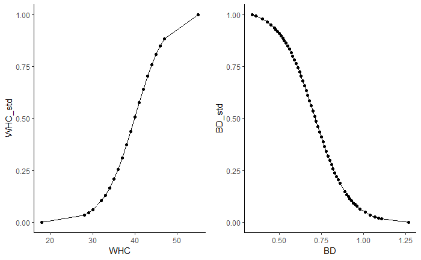

```r
ggarrange(
  dat_std_fpl %>%
    ggplot(aes(x = WHC, y = WHC_std)) +
    geom_point() +
    geom_line() +
    theme_classic() +
    theme(strip.background = element_blank()),

  dat_std_fpl %>%
    ggplot(aes(x = BD, y = BD_std)) +
    geom_point() +
    geom_line() +
    theme_classic() +
    theme(strip.background = element_blank())
)
```

Both indicators show the expected sigmoidal relationship with their respective original relatives.

## 3.2 Monomodal relationships with functions: the `Score.mod` function

Following Silva-Olaya et al. (2022), monomodal relationships can be defined as being composed of two logistic functions: one ascending up to the mode and the other descending from the mode. For modelling both parts we will use `Score.fpl` as previously defined. So, our related R function called `Score.mod`, is defined as:

```r
Score.mod <-
  function(x,
           mod_x = median(x),
           ymin_left = 0,
           ymin_right = ymin_left,
           sleft = 0.1,
           sright = sleft) {
    x <- (x)
    mod_x <- (mod_x)

    xleft <- x[x <= mod_x]
    xright <- x[x > mod_x]

    xleft_scaled <-
      rescale(
        Score.fpl(
          xleft,
          s = sleft,
          ascend = TRUE,
          ymin = ymin_left,
          x50 = quantile(xleft, 0.15),
          rescale = FALSE
        ),
        to = c(ymin_left, 1)
      )

    xright_scaled <-
      rescale(
        Score.fpl(
          xright,
          s = sright,
          ascend = FALSE,
          ymin = ymin_right,
          x50 = quantile(xright, 0.85),
          rescale = FALSE
        ),
        to = c(ymin_right, 1)
      )

    xscaled <- numeric()
    xscaled[x <= mod_x] <- xleft_scaled
    xscaled[x > mod_x] <- xright_scaled
    xscaled
  }
```

Where:

- *mod_x* sets the value of (*x*) for which a maximum value of the function is reached. Default *x* value is the median of *x*.
- *ymin_left* sets the minimum possible value for value *y_{scaled}* to the left of *mod_x*. Set to a default of 0.
- *ymin_right* sets the minimum possible value for value *y_{scaled}* to the right of *mod_x*. Set to a default equal to *ymin_left*.
- *sleft*, the rate of change to the left of *mod_x*, with a default value of 0.1.
- *sright*, the rate of change to the right of *mod_x*, with a default value equal to *sleft*.

*ymin_left* and *ymin_right* can be set in case the minimum achievable value of the standardized indicator is different to both sides of the curve.

### 3.2.1 Using the `Score.mod` function

Lets standardize pH for ilustrating how to use the `Score.mod`. In principle, pH modifies soil fertility (it controls availability of plant nutrients). Availability is in general higher at intermediate ph values (~ 6.0), decreasing at lower and higher values. So we can set the value of mod_x = 6. Furthermore, in our dataset the highest pH value is 6.87, while the lowest is 3.35. In this case, using different *ymin_left* and *ymax_left* values seems to make sense, as nutrient availability at pH = 6.87 might be similar to that found at pH around ~ 4.7 . So lets use `Score.mod` function.

```r
dat_std_fpl <- dat_std_fpl %>%
  mutate(pH_std = Score.mod(pH, mod_x = 6, ymin_left = 0, ymin_right = 0.8, sleft = 0.08, sright = 0.2))
```

Let’s see how standardized pH relate to original pH values:

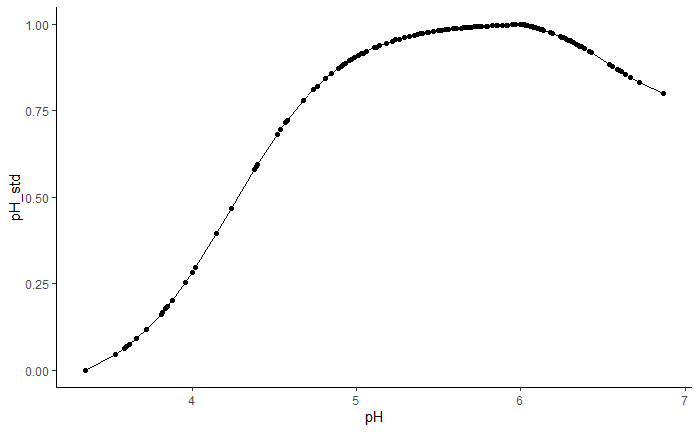

```r
  dat_std_fpl %>%
    ggplot(aes(x = pH, y = pH_std)) +
    geom_point() +
    geom_line() +
    theme_classic() +
    theme(strip.background = element_blank())
```

The standardized pH shows a monomodal asymetric relationship to pH, as defined by the parameters ymin_left and ymin_right, as well as the differential rate of change (s values) to both sides of the pH mode.

## 3.3 Comments on the standardization produced by `Score.fpl` and `Score.mod`

Contrary to the original approach by Silva-Olaya et al. (2022), our parametrization does not require to know in advance the maximum and minimum possible values for each original indicator, which seems to be quite unlikely for poorly studied locations or those underrepresented in soil assessments. It rather requires setting maximum and minimum values of the standardized index (default [0,1]), the value of the original indicator *x* for which *y_{scaled}* might reach 50% of *y_{max}* (*x_{50}*), and the rate of change *s*. *x_{50}* might be defined by convenience as the median of *x* (the default), or based on expert knowledge.

In the caso of `Score.fpl`, another advantage is the possibility to easily define the type of relationship between the original indicator and the standardized indicator: positive or negative. For easy of interpretation (and based on some basic intuition), a higher value of a standardized indicator should imply higher function. This is achieved by setting the value of the *ascend* argument. If TRUE, it sets a positive relationship (the default), if FALSE it sets a negative one. This way, standardized indicators are allowed to always have a positive relationship with the function.

# 4 3. Integration of indices into a single indicator per function

For those cases in which a function has been evaluated using more than one variable, it is neccessary to construct a composite indicator. Here we propose the use of an ordination procedure (a Principal Component Analysis, PCA) to objectively define a composite indicator. Ordination allows to assign objective weights for each standardized indicator while summarizing them in a composite indicator for a particular function.

Here we define the function `Ind_uniq`, which aggregate individual standardized indicators into a single indicator following Silva-Olaya et al. (2022).

```r
Ind_uniq <- function (data,
                      scale = FALSE,
                      redirect = FALSE) {
  require(ggplot2)
  require(ggvegan)

  ordenacion <- rda(data, scale = scale)

  naxis <- eigenvals(ordenacion) > mean(eigenvals(ordenacion))

  varscores <- scores(ordenacion, choices = c(naxis))$species

  weiscores <- as.matrix(data) %*% varscores

  varexp <- eigenvals(ordenacion) / sum(eigenvals(ordenacion))

  indice <- as.matrix(weiscores) %*% varexp[naxis]

  indice2 <- rescale(if (redirect == TRUE) {
    -1 * indice
  } else {
    indice
  })

  resultado <- list(
    grafica = autoplot(ordenacion) +
      labs(title = "Principal Component Analysis"),
    indice = indice2
  )

  return(resultado)

}
```

`Ind_uniq` requires three arguments:

- *data*, a dataframe containing the variables to be used in the construction of the unique indicator
- *scale*, specifyng wether standardization should proceed before ordination. Default is *FALSE*, as variables should have already benn scaled using the `Score.fpl` function.
- *redirect*, setting wether the single indicator should be redirected so that higher values represent higher function. Its default value is FALSE. Should be used when after calculating the single indicator, its scale results in values from -1 to 0, with -1 indicating the highest function.

### 4.0.1 Using the `Ind_uniq` function

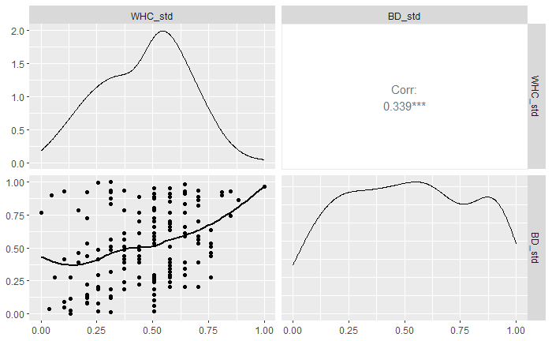

The variables show different distributions and a slight but significant correlation, which the ordination procedure should deal with. So lets calculate our single indicator for water retention function.

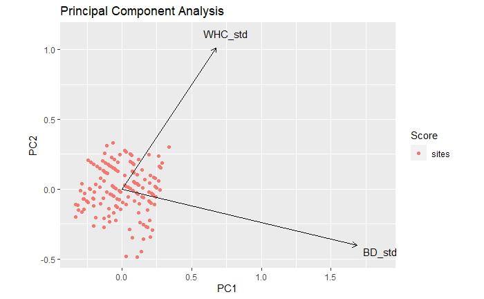

```r
Indi_alm_fpl <- Ind_uniq(dat_wr_fpl)

Indi_alm_fpl$grafica
```

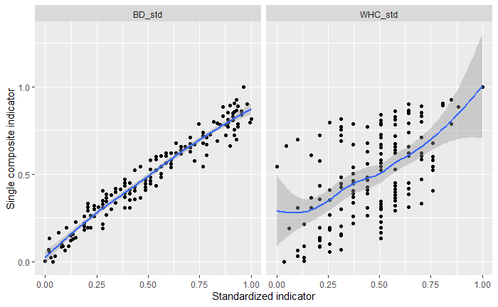

```r
dat_wr_fpl %>%
  mutate(WR_indic = Indi_alm_fpl$indice) %>%
  pivot_longer(cols = 1:2, names_to = "Variable", values_to = "Valor") %>%
  ggplot(aes(x= Valor, y = WR_indic)) +
  geom_point() +
  geom_smooth() +
  facet_wrap(~Variable) +
  labs( x = "Standardized indicator", y = "Single composite indicator")
```

# 5 Calculating the multifunctionality index

Finnally, as we can give all the functions the same importance, and as their unique indicators are all scaled [0,1], the multifunctionality index can be calculated as a simple sum of the unique indicator for each function. For our example, we only have two functions: water retention and nutrient availability (as measured by pH). So we can simply add their values to calculate a *Multifunc* value:

```r
dat_std_fpl <- dat_std_fpl %>%
  mutate(WR_indic = Indi_alm_fpl$indice) %>%
  rowwise() %>%
  mutate(Multifunc = pH_std + WR_indic)

dat_std_fpl
```

| WHC | BD | pH | WHC_std | BD_std | pH_std | WR_indic | Multifunc |
| --- | --- | --- | --- | --- | --- | --- | --- |
| 40 | 0.93 | 6.25 | 0.50736806 | 0.10266202 | 0.96391359 | 0.195045132 | 1.15895873 |
| 37 | 0.86 | 6.35 | 0.31122862 | 0.18839607 | 0.94058900 | 0.200571602 | 1.14116060 |
| 38 | 0.75 | 6.25 | 0.37278323 | 0.41143339 | 0.96391359 | 0.388843287 | 1.35275688 |
| 38 | 0.76 | 5.60 | 0.37278323 | 0.38736026 | 0.98791714 | 0.370542969 | 1.35846011 |
| 40 | 0.45 | 4.40 | 0.50736806 | 0.95196167 | 0.59583494 | 0.840679858 | 1.43651480 |
| 39 | 0.63 | 4.54 | 0.43886159 | 0.70361123 | 0.69646711 | 0.631051087 | 1.32751820 |
| 44 | 0.71 | 5.83 | 0.75901536 | 0.51122965 | 0.99651881 | 0.582165707 | 1.57868452 |
| 40 | 0.67 | 6.07 | 0.50736806 | 0.61102590 | 0.99337916 | 0.581501636 | 1.57488079 |
| 38 | 0.86 | 5.95 | 0.37278323 | 0.18839607 | 0.99915239 | 0.219291069 | 1.21844346 |
| 41 | 0.66 | 6.32 | 0.57587454 | 0.63509903 | 0.94809579 | 0.620635562 | 1.56873135 |

[output cut: 158 more lines]

```r
NA
```

We can visualize both the original functions and the multifunctionality index using flower plots:

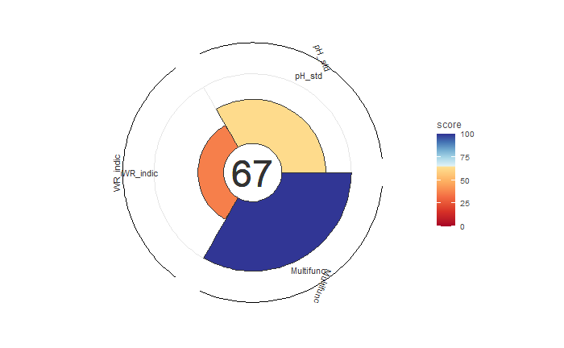

# 6 Bibliography

R Core Team. 2023. “R: A language and environment for statistical computing.” Vienna, Austria: R Foundation for Statistical Computing. http://www.r-project.org/.

Silva-Olaya, Adriana M., Fausto A. Ortíz-Morea, Gina P. España-Cetina, Andrés Olaya-Montes, Daniel Grados, Alexandros Gasparatos, and Mauricio Roberto Cherubin. 2022. “Composite index for soil-related ecosystem services assessment: Insights from rainforest-pasture transitions in the Colombian Amazon.” *Ecosystem Services* 57 (July): 101463. https://doi.org/10.1016/j.ecoser.2022.101463.

[^1]: Instituto de Investigaciones en Ecosistemas y Sustentabilidad, Universidad Nacional Autónoma de México, fmora@cieco.unam.mx
[^2]: Instituto de Investigaciones en Ecosistemas y Sustentabilidad, Universidad Nacional Autónoma de México, abaleon@cieco.unam.mx
[^3]: Instituto de Investigaciones en Ecosistemas y Sustentabilidad, Universidad Nacional Autónoma de México, mgavito@cieco.unam.mx